# Project1: Lyrics Analysis

Qing Gao

This report focuses on the analysis of the song lyrics and the differences between several music genre.

## Explore the Data

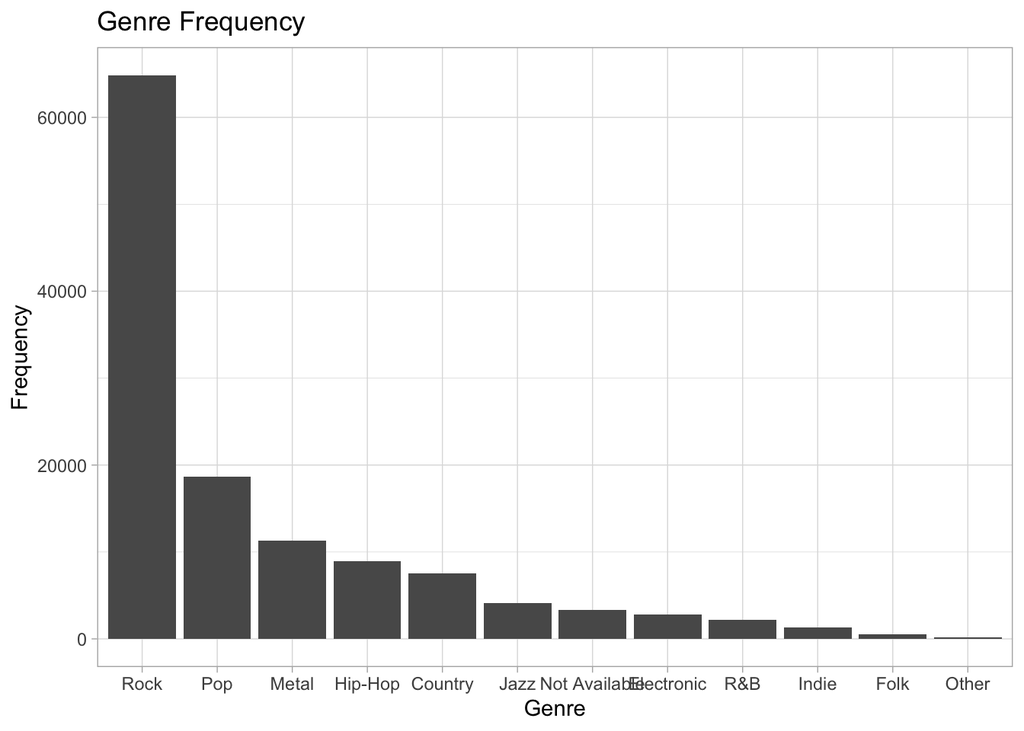

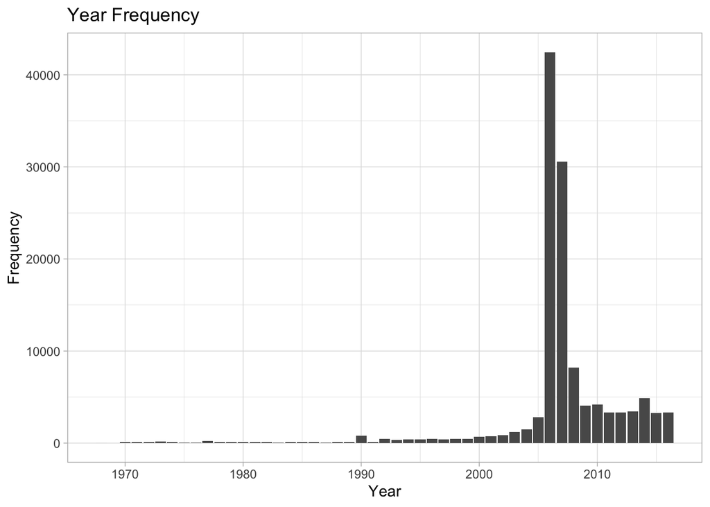

First, let’s take a look of the dataset and explore some features of it. From the genre frequency plot, there is more data about the Rock, Pop and Metal music data in the dataset. Therefore, I will explore more about these major music genre later and find out their differences.

The year frequency plot shows that the lyrics dataset mainly covers data from 1970 to 2016. There is more data in year 2006 and 2007.

## Sentiment Analysis

Since we have more information on rock, pop and metal music, we will compare between these three music genre with the tool of sentiment analysis. In the sentiment anlaysis, I use the package `get_sentiments("nrc")` to assign each word with an emotion from the following ten emotions, which are positive, negative, joy, sadness, fear, anticipation, trust, anger, disgust and surprise.

### Genre & Emotion: Rock

Let’s look at Rock music at first, and do a sentiment analysis on its lyrics.

```
## # A tibble: 10 x 2
##    sentiment    percent
##    <chr>          <dbl>
##  1 positive      0.172
##  2 negative      0.162
##  3 joy           0.107
##  4 sadness       0.0986
##  5 fear          0.0938
##  6 anticipation  0.0902
##  7 trust         0.0890
##  8 anger         0.0758
##  9 disgust       0.0585
## 10 surprise      0.0535
```

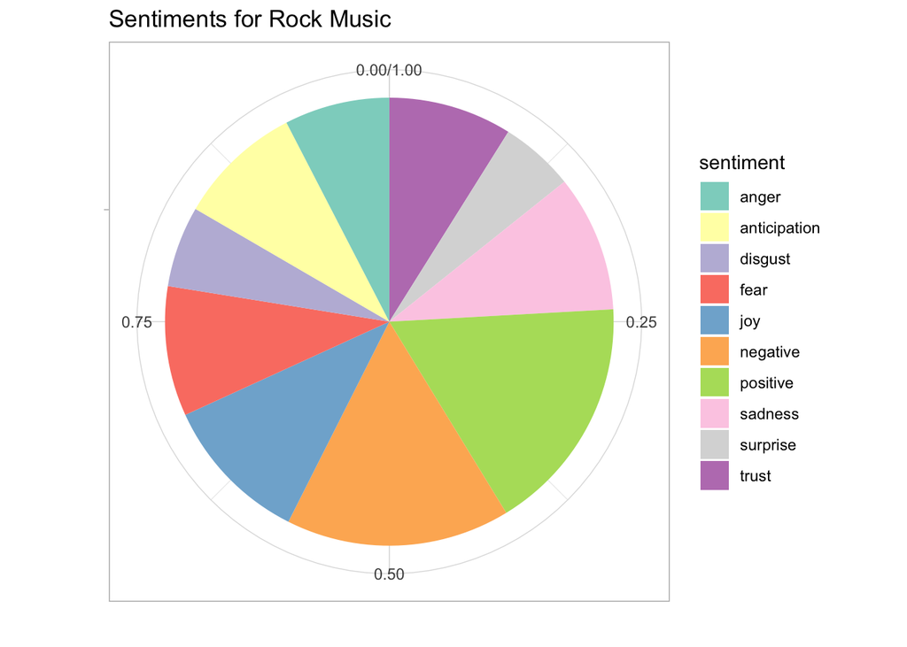

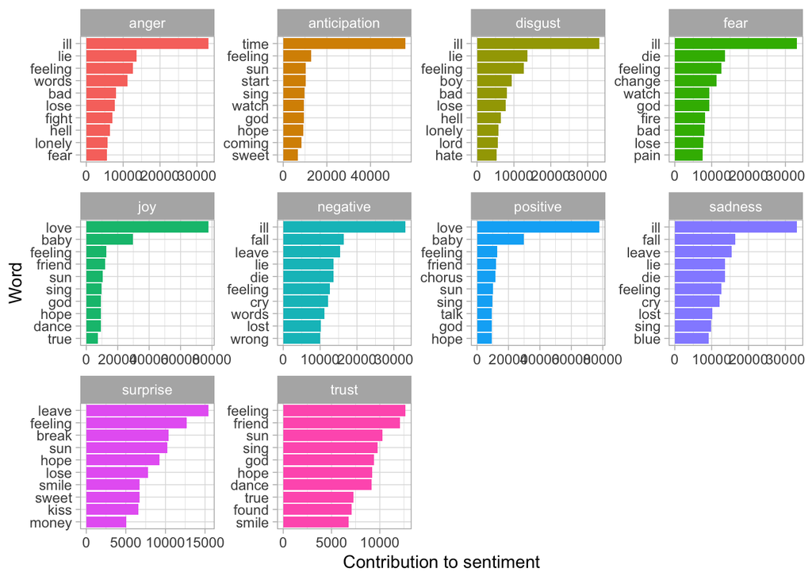

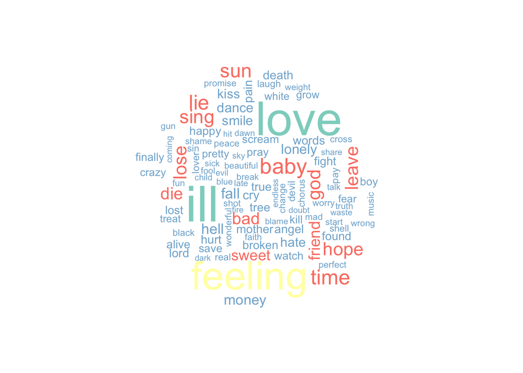

When I look closer to the details of rock music’s lyrics. The most frequent word for positive sentiment is “love” and for negative one is “ill”. From the word cloud, I can also see that “love” and “ill” appear the most frequent in the rock music. The lyrics of the Rock music is straightforward to express its emotion.

### Genre & Emotion: Pop

Let’s look at the pop music.

```
## # A tibble: 10 x 2
##    sentiment    percent
##    <chr>          <dbl>
##  1 positive      0.200
##  2 negative      0.140
##  3 joy           0.139
##  4 sadness       0.0884
##  5 anticipation  0.0880
##  6 trust         0.0865
##  7 fear          0.0807
##  8 anger         0.0697
##  9 disgust       0.0538
## 10 surprise      0.0536
```

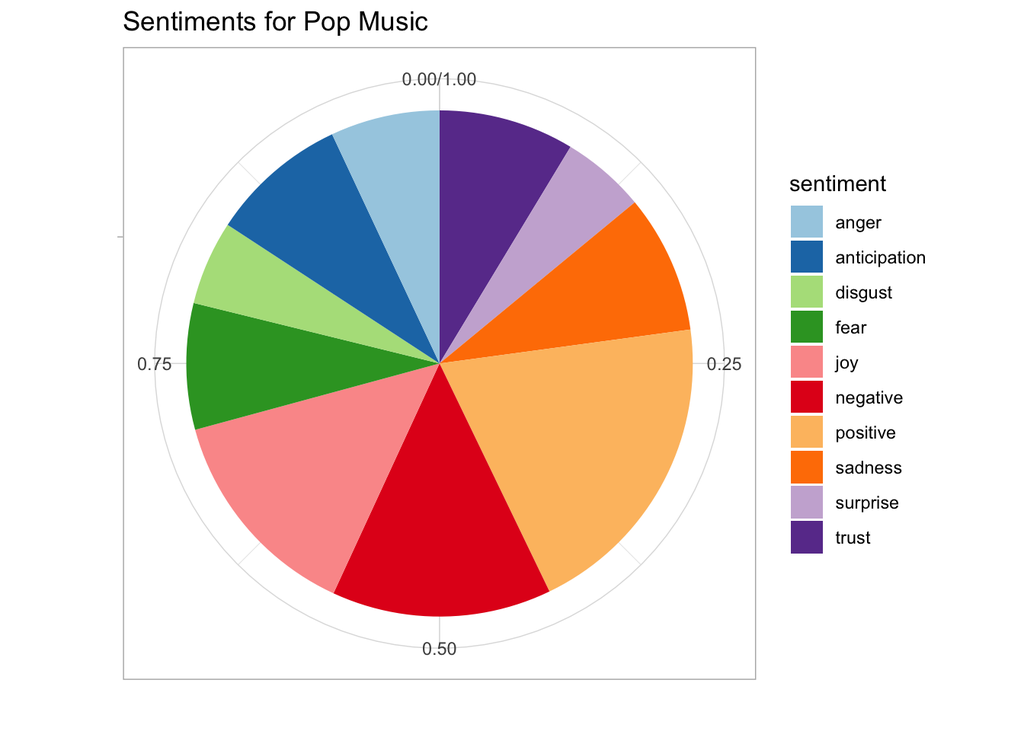

According to the table and pie chart, pop music has more positive sentiment than that of rock music. There are 34% of sentiment are positive and joy in pop music lyrics.

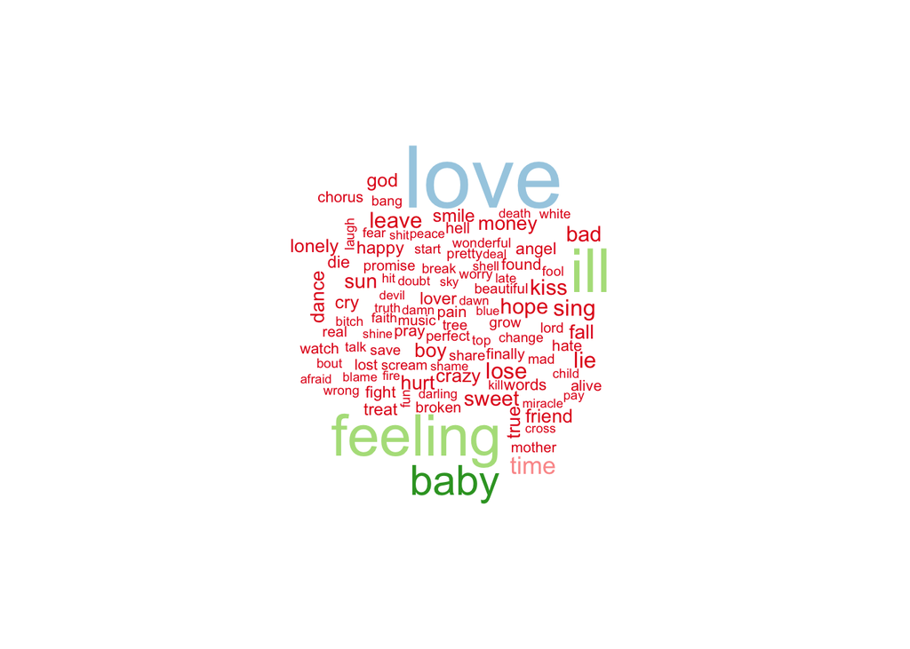

From the detailed analysis of the pop music lyrics, “love”, “feeling” and ‘baby’ dominates the lyrics. In short conclusion, pop music has more positive and joy sentiments. For example, its lyrics contains ‘laugh’, ‘sweet’, ‘angel’, ‘baby’ and other words that express a positive feeling and emotion.

### Genre & Emotion: Metal

```
## # A tibble: 10 x 2
##    sentiment    percent
##    <chr>          <dbl>
##  1 negative      0.198
##  2 positive      0.130
##  3 fear          0.126
##  4 sadness       0.116
##  5 anger         0.0958
##  6 anticipation  0.0774
##  7 trust         0.0747
##  8 disgust       0.0709
##  9 joy           0.0657
## 10 surprise      0.0458
```

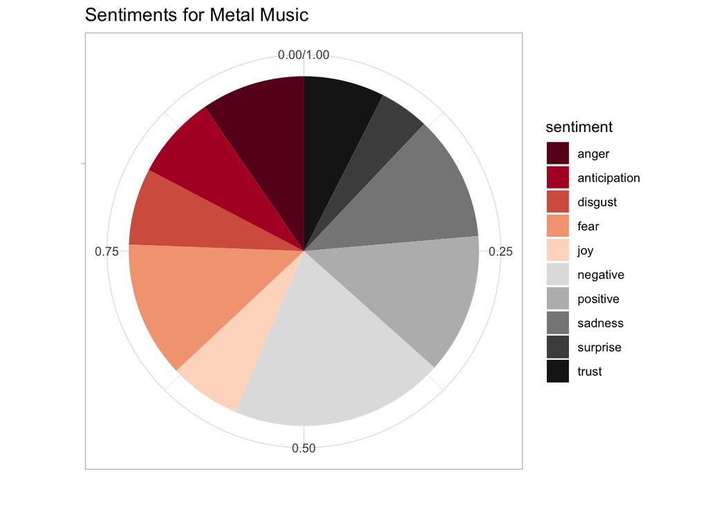

Metal music is different from both rock and pop music. It has more negative, fear, sadness and anger sentiments in the lyrics. Most of its lyrics have negative emotions.

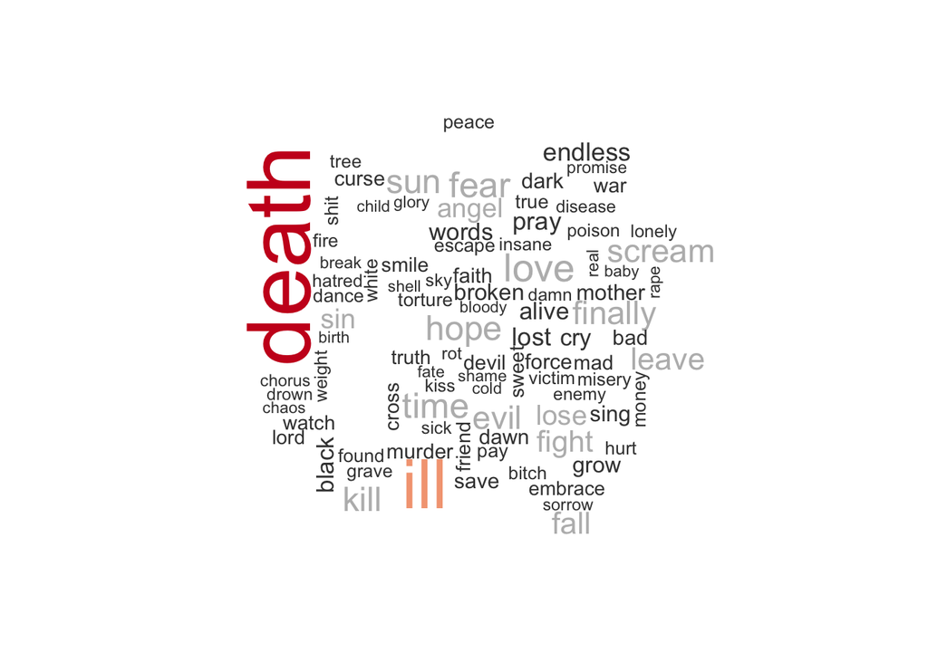

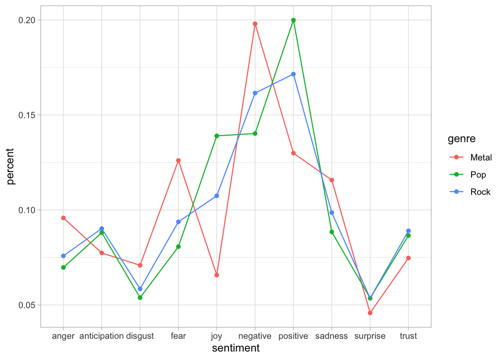

From the line plot we can see that Metal music has more variation in its emotion and sentiments, and the sentiment line is more curved compared to the other two lines. For example, it has more negative sentiments but less joy sentiments. In the contrast, the Rock and Pop music mainly have positive sentiments.

## Topic Modeling

### Rock

```
##
##   1   2   3   4   5
## 484 388 375 381 377
```

```
##      Topic 1 Topic 2 Topic 3 Topic 4 Topic 5
## [1,] "time"  "ill"   "love"  "call"  "day"
## [2,] "ive"   "eyes"  "youre" "boy"   "night"
## [3,] "life"  "dream" "baby"  "play"  "light"
## [4,] "world" "fall"  "girl"  "dance" "cry"
## [5,] "live"  "hold"  "run"   "rock"  "die"
## [6,] "heart" "hand"  "home"  "roll"  "hear"
```

### Pop

```
##
##   1   2   3   4   5
## 309 369 477 390 460
```

```
##      Topic 1  Topic 2 Topic 3 Topic 4   Topic 5
## [1,] "girl"   "run"   "day"   "love"    "time"
## [2,] "boy"    "fall"  "life"  "baby"    "heart"
## [3,] "gotta"  "home"  "world" "youre"   "ive"
## [4,] "stop"   "hand"  "night" "ill"     "mind"
## [5,] "talk"   "hes"   "dream" "feeling" "waiting"
## [6,] "chorus" "free"  "live"  "hold"    "cry"
```

### Metal

```
##
##   1   2   3   4   5
## 396 442 335 443 389
```

```
##      Topic 1 Topic 2 Topic 3   Topic 4 Topic 5
## [1,] "die"   "time"  "love"    "burn"  "world"
## [2,] "dead"  "life"  "chorus"  "dark"  "eyes"
## [3,] "death" "live"  "fucking" "light" "heart"
## [4,] "blood" "youre" "head"    "night" "mind"
## [5,] "kill"  "day"   "move"    "fire"  "dream"
## [6,] "hate"  "ive"   "ill"     "sky"   "hand"
```

In the topic modeling, I randomly selected 2000 data points from each genre’s datasets. The results of the topic modeling show the different five topics under the music genre rock, pop and metal.

## Conclusion

The dataset lyrics contains 100,000+ lyrics information. Since the dataset contains overwhelming information on the lyrics, this report focuses on the comparison between three music genre, which are rock, pop and metal music.

From the sentiment analysis, rock and pop music have more positive and joy sentiments than the metal music does. While lyrics in metal music has a lot of negative and sadness sentiments.

The topic modeling finds out five topics and top six terms for each topic respectively. Each genre has different focus of the topic.